# Plotting

GoogleMapsAPI.jl ships two plotting paths:

1. **`mapplot`** — a one-liner that fetches a Static-Maps background and overlays markers/polylines for any response. Lives in the Makie extension.
2. **GeoInterface trait conformance** — the wrapper types (`GMPoint`, `GMLineString`, `GMFeature`, `GMFeatureCollection`) implement the GeoInterface traits, so **any** GeoInterface-aware plotting tool (notably [GeoMakie.jl](https://geo.makie.org)) can consume GoogleMapsAPI responses directly — with real projections, base maps, and the usual Makie layout machinery.

**Note**

The examples on this page make real calls to the Google Maps Platform. Set `ENV["GOOGLE_MAPS_API_KEY"]` (or pass `key=...` to each call) before rendering the page locally.

```julia
using GoogleMapsAPI
using CairoMakie, FileIO, Makie
CairoMakie.activate!(type = "png")
```

## The built-in `mapplot`

Load Makie (plus a backend and `FileIO`) alongside GoogleMapsAPI, and `mapplot(x)` fetches a static map sized to the response’s bounding box and overlays everything it can extract.

### A geocoded address

[figure not shown]

```julia
r = geocode("1600 Amphitheatre Pkwy, Mountain View, CA")
mapplot(r)
```

### A computed route, on satellite imagery

[figure not shown]

```julia
route = compute_routes(
    (35.9132, -79.0822),            # Carrboro, NC
    (38.9805, -77.0915);            # Bethesda, MD
    routing_preference = "TRAFFIC_AWARE_OPTIMAL",
)
mapplot(route; maptype = "satellite", size = (800, 600))
```

### Elevation samples along a transect

[figure not shown]

```julia
elevations = elevation([(38.5, -120.2), (40.7, -120.95), (43.25, -126.45)])
mapplot(elevations; maptype = "terrain")
```

### Styling kwargs

| Kwarg | Default | Purpose |
| --- | --- | --- |
| `maptype` | `"roadmap"` | `"roadmap"`, `"satellite"`, `"terrain"`, `"hybrid"` |
| `size` | `(640, 640)` | Image pixel dimensions |
| `padding` | `0.15` | Fraction of bbox span added as margin |
| `markercolor` | `:red` | Scatter colour for points |
| `markersize` | `12` | Scatter size |
| `linecolor` | `:dodgerblue` | Polyline colour |
| `linewidth` | `3` | Polyline width |

Everything else — `scale`, `language`, `region`, `style`, `client`, `key`, `timeout`, etc. — is forwarded to `static_map`.

### How it works

Internally, `mapplot`:

1. Calls `features(x)` → extracts every `GMPoint` and `GMLineString`.
2. Computes a bounding box and a Web-Mercator-fit zoom level.
3. Fetches the Static Maps image via `static_map(...)` and decodes the PNG bytes with `FileIO`.
4. Draws the image, then scatters markers and draws polylines at their projected pixel coordinates — so overlays line up with the real map.

Because it goes through `features(x)`, *any* response type works — even a raw `JSON.Object` you built yourself.

## GeoInterface: use responses anywhere

The real integration happens one level up. The four wrapper types (`GMPoint`, `GMLineString`, `GMFeature`, `GMFeatureCollection`) implement the GeoInterface traits, so every GeoInterface-aware package sees them as native geometries.

### Traits

```julia
using GeoInterface

p = GMPoint(37.4, -122.1)
GeoInterface.isgeometry(p), GeoInterface.geomtrait(p),
GeoInterface.x(p), GeoInterface.y(p)
```

```
(true, PointTrait(), -122.1, 37.4)
```

```julia
ls = GMLineString([GMPoint(0.0, 0.0), GMPoint(1.0, 2.0), GMPoint(3.0, 4.0)])
GeoInterface.geomtrait(ls), GeoInterface.ngeom(ls), GeoInterface.getgeom(ls, 2)
```

```
(LineStringTrait(), 3, GMPoint(lat=1.0, lng=2.0))
```

```julia
fc = features(geocode("Carrboro, NC"))
f  = GeoInterface.getfeature(fc, 1)
(GeoInterface.geometry(f), GeoInterface.properties(f).formatted_address)
```

```
(GMPoint(lat=35.9101438, lng=-79.0752895), "Carrboro, NC, USA")
```

### What this unlocks

Anything in the JuliaGeo ecosystem that accepts GeoInterface geometries now accepts GoogleMapsAPI responses — including:

- [GeoMakie.jl](https://geo.makie.org) — geographic plotting with map projections (see the next section).
- GeoJSON.jl — serialise a feature collection to GeoJSON.
- ArchGDAL.jl — reproject, transform, or export to shapefile/GeoPackage/etc.
- GeometryOps.jl — distance, area, simplification, clipping.
- Shapefile.jl, Tables.jl-backed workflows, etc.

## GeoMakie integration

GeoMakie plots lat/lng data on a `GeoAxis` that handles projections. Because `GMPoint` implements `PointTrait`, you can pull points out of any response and hand them straight to Makie.

```julia
using GeoMakie
```

### Scatter: extract points, plot on a projected axis

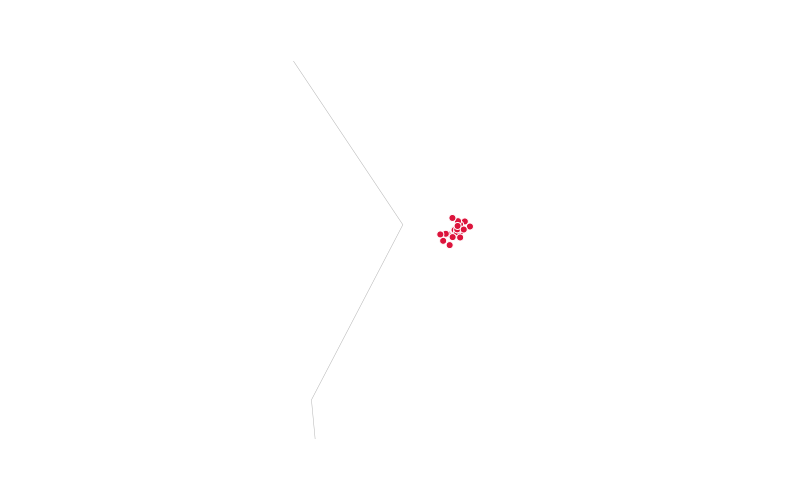

```julia
r = places("coffee"; location = (37.7749, -122.4194), radius = 2000)
pts = points(r)

fig = Figure(size = (800, 500))
ax  = GeoAxis(fig[1, 1]; dest = "+proj=natearth",
              xticks = -180:30:180, yticks = -90:30:90)
lines!(ax, GeoMakie.coastlines(); color = :grey70, linewidth = 0.5)
scatter!(ax,
    [GeoInterface.x(p) for p in pts],
    [GeoInterface.y(p) for p in pts];
    color = :crimson, markersize = 10, strokecolor = :white, strokewidth = 1,
)
xlims!(ax, -123, -122)
ylims!(ax, 37.5, 38.0)
fig
```

### Routes: lines on a projected axis

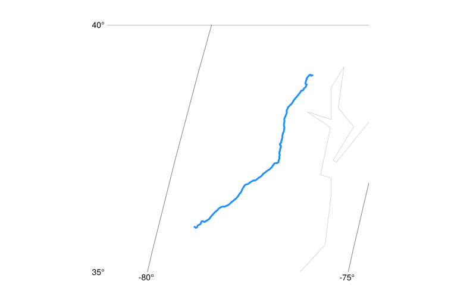

```julia
route = compute_routes((35.9132, -79.0822), (38.9805, -77.0915))

fig = Figure(size = (800, 500))
ax  = GeoAxis(fig[1, 1]; dest = "+proj=natearth",
              xticks = -180:5:180, yticks = -90:5:90)
lines!(ax, GeoMakie.coastlines(); color = :grey70, linewidth = 0.5)
for ls in linestrings(route)
    lines!(ax,
        [GeoInterface.x(pt) for pt in ls],
        [GeoInterface.y(pt) for pt in ls];
        color = :dodgerblue, linewidth = 3,
    )
end
xlims!(ax, -81, -76)
ylims!(ax, 35, 40)
fig
```

### One function for anything

Treat a response generically — plot every point or every line without branching on which endpoint produced it — by walking the feature collection:

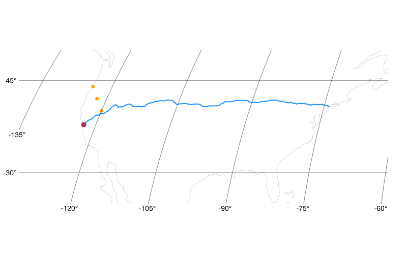

```julia
function geoplot!(ax, x; kwargs...)
    for f in features(x)
        g = GeoInterface.geometry(f)
        if g isa GMPoint
            scatter!(ax, [GeoInterface.x(g)], [GeoInterface.y(g)]; kwargs...)
        elseif g isa GMLineString
            lines!(ax,
                [GeoInterface.x(pt) for pt in g],
                [GeoInterface.y(pt) for pt in g];
                kwargs...,
            )
        end
    end
    ax
end

fig = Figure(size = (800, 500))
ax  = GeoAxis(fig[1, 1]; dest = "+proj=natearth",
              xticks = -180:15:180, yticks = -90:15:90)
lines!(ax, GeoMakie.coastlines(); color = :grey70, linewidth = 0.5)
geoplot!(ax, geocode("San Francisco, CA"); color = :crimson, markersize = 14)
geoplot!(ax, compute_routes((37.77, -122.42), (40.71, -74.01));
             color = :dodgerblue, linewidth = 2)
geoplot!(ax, elevation([(40, -120), (42, -122), (44, -124)]);
             color = :orange, markersize = 10)
xlims!(ax, -130, -65)
ylims!(ax, 25, 50)
fig
```

### When to use what

| Goal | Use |
| --- | --- |
| Quick look at a response on a real base map | `mapplot(x)` |
| Publication-quality projection / custom styling | GeoMakie + wrappers |
| Hand data to another geospatial tool (GeoJSON, GDAL, …) | `features(x)` or `points(x)` / `linestrings(x)` |

`mapplot` is great for exploration; GeoMakie + GeoInterface is the right path when you want to compose with other layers, apply a projection, or integrate a response into a larger visualisation.